# Greenland Ice Glacier Analysis - Data Visualization Project

Group project done for the Data science course

## Introduction

### Importing packages and loading data

- This project uses numpy, pandas to wrangle the data and matplotlib to visualize the data
- I am loading the data from my google drive by using the mount method in colab

```python
import pandas as pd
import numpy as np
from matplotlib import pyplot as plt
from google.colab import drive
drive.mount('/content/drive', force_remount = True)
```

```python
df = pd.read_csv(f"/content/drive/MyDrive/DataScience/Data/MB_SMB_D_BMB.csv")
df.head()
```

|  | time | MB | MB_err | SMB | SMB_err | D | D_err | BMB | BMB_err |
| --- | --- | --- | --- | --- | --- | --- | --- | --- | --- |
| 0 | 1840-01-01 | 0.267185 | 0.373477 | 1.407972 | 0.302918 | 1.079574 | 0.215092 | 0.061212 | 0.038220 |
| 1 | 1841-01-01 | 0.300225 | 0.357615 | 1.438253 | 0.284199 | 1.079574 | 0.213832 | 0.058454 | 0.037356 |
| 2 | 1842-01-01 | -0.284109 | 0.357375 | 0.857085 | 0.281043 | 1.079574 | 0.217393 | 0.061620 | 0.038363 |
| 3 | 1843-01-01 | -0.320739 | 0.372270 | 0.822635 | 0.301422 | 1.079574 | 0.214927 | 0.063799 | 0.039190 |
| 4 | 1844-01-01 | -0.473110 | 0.369937 | 0.670860 | 0.298957 | 1.079574 | 0.214297 | 0.064395 | 0.039434 |

```python
df.info()
```

```
<class 'pandas.core.frame.DataFrame'>
RangeIndex: 13629 entries, 0 to 13628
Data columns (total 9 columns):
 #   Column   Non-Null Count  Dtype
---  ------   --------------  -----
 0   time     13629 non-null  object
 1   MB       13629 non-null  float64
 2   MB_err   13629 non-null  float64
 3   SMB      13629 non-null  float64
 4   SMB_err  13629 non-null  float64
 5   D        13629 non-null  float64
 6   D_err    13629 non-null  float64
 7   BMB      13629 non-null  float64
 8   BMB_err  13629 non-null  float64
dtypes: float64(8), object(1)
memory usage: 958.4+ KB
```

### Data Wrangling

- As we can see, the data doesn't have any missing values.
- The attribute time is of the type object, we should convert it to the datetime data type.
- And we should drop some columns as we don't need all of them for furthur classification, this is called future selection.
- For the visualization we don't need to consider the error in calculation, so we can drop all the err columns.
- And if we observe the time column the data till 1985 is annual and from then it's daily so, I choose to group data to make the whole data similar.

```python
df["time"] = pd.to_datetime(df["time"]) #changing data type
dfs = df[["MB","SMB","BMB", "D"]].copy() #feature selection
dfs["year"] = df["time"].dt.year #adding a year column by extracting year from time attribute
dfm = dfs.groupby(dfs["year"]).mean() #grouping by year
```

After cleaning the data, we endup like this

- As we grouped data on year, year is the index now

```python
dfm.info()
```

```
<class 'pandas.core.frame.DataFrame'>
Int64Index: 183 entries, 1840 to 2022
Data columns (total 4 columns):
 #   Column  Non-Null Count  Dtype
---  ------  --------------  -----
 0   MB      183 non-null    float64
 1   SMB     183 non-null    float64
 2   BMB     183 non-null    float64
 3   D       183 non-null    float64
dtypes: float64(4)
memory usage: 7.1 KB
```

### Outlier Analysis

We plot the boxplots for all the attributes to find the outliers.

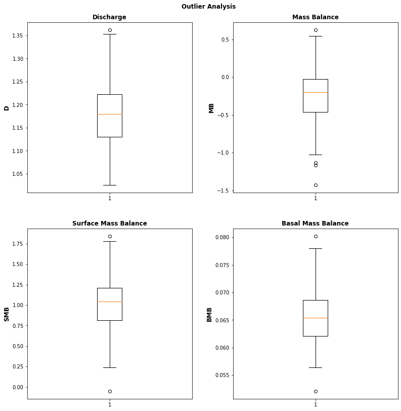

```python
fig, ax = plt.subplots(2,2, figsize=(12,12))
fig.suptitle("Outlier Analysis",fontsize='large', fontweight='bold')
fig.tight_layout(pad=5.0)

dic = ax[0][0].boxplot(dfm["D"])
ax[0][0].set_title("Discharge",fontsize='large', fontweight='bold')
ax[0][0].set_ylabel("D",fontsize='large', fontweight='bold')

ax[0][1].boxplot(dfm["MB"])
ax[0][1].set_title("Mass Balance",fontsize='large', fontweight='bold')
ax[0][1].set_ylabel("MB",fontsize='large', fontweight='bold')

ax[1][0].boxplot(dfm["SMB"])
ax[1][0].set_title("Surface Mass Balance",fontsize='large', fontweight='bold')
ax[1][0].set_ylabel("SMB",fontsize='large', fontweight='bold')

ax[1][1].boxplot(dfm["BMB"])
ax[1][1].set_title("Basal Mass Balance",fontsize='large', fontweight='bold')
ax[1][1].set_ylabel("BMB",fontsize='large', fontweight='bold')

plt.show()
```

As the data is not so large, I have manually identified the outliers with this code and droped those rows

```python
dfm["rank"] = dfm["MB"].rank(ascending = True)
dfm = dfm[(dfm["rank"] != 1.0)]
dfm = dfm[(dfm["rank"] != 2.0)]
dfm = dfm[(dfm["rank"] != 3.0)]
dfm["rank"] = dfm["D"].rank(ascending = False)
dfm = dfm[(dfm["rank"] != 1.0)]
dfm["rank"] = dfm["SMB"].rank(ascending = False)
dfm = dfm[(dfm["rank"] != 1.0)]
dfm["rank"] = dfm["BMB"].rank(ascending = True)
dfm = dfm[(dfm["rank"] != 1.0)]
dfm.shape
```

```
(177, 5)
```

After deleting the outliers the boxplots looks clean, so this data is good to fit the models.

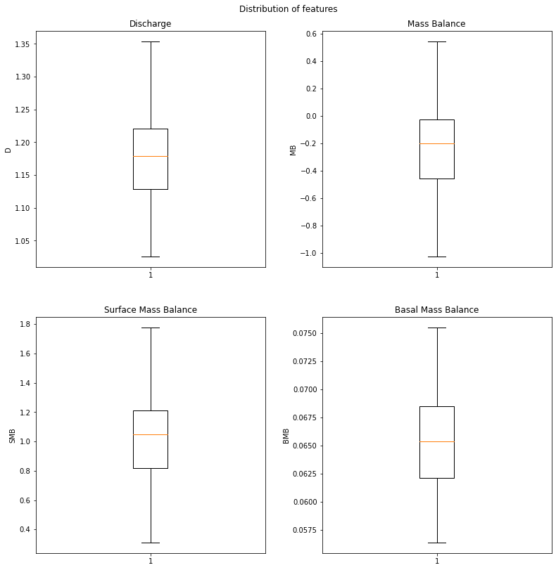

```python
fig, ax = plt.subplots(2,2, figsize=(12,12))
fig.suptitle("Distribution of features")
fig.tight_layout(pad=5.0)

ax[0][0].boxplot(dfm["D"])
ax[0][0].set_title("Discharge")
ax[0][0].set_ylabel("D")

ax[0][1].boxplot(dfm["MB"])
ax[0][1].set_title("Mass Balance")
ax[0][1].set_ylabel("MB")

ax[1][0].boxplot(dfm["SMB"])
ax[1][0].set_title("Surface Mass Balance")
ax[1][0].set_ylabel("SMB")

ax[1][1].boxplot(dfm["BMB"])
ax[1][1].set_title("Basal Mass Balance")
ax[1][1].set_ylabel("BMB")

plt.show()
```

```python
dfm.shape
```

```
(177, 5)
```

## Data visualization

### How the data is distributed

- By using the histograms we can see how the data is centralized towards the mean.

[figure not shown]

```python
fig, ax = plt.subplots(2,2, figsize=(12,12))
fig.suptitle("Distribution of features",fontsize='large', fontweight='bold')
fig.tight_layout(pad=5.0)

ax[0][0].hist(dfm["D"])
ax[0][0].set_title("Discharge Distributuion",fontsize='large', fontweight='bold')
ax[0][0].set_xlabel("D",fontsize='large', fontweight='bold')
ax[0][0].set_ylabel("Density",fontsize='large', fontweight='bold')

ax[0][1].hist(dfm["MB"])
ax[0][1].set_title("Mass Balance Distributuion",fontsize='large', fontweight='bold')
ax[0][1].set_xlabel("MB",fontsize='large', fontweight='bold')
ax[0][1].set_ylabel("Density",fontsize='large', fontweight='bold')

ax[1][0].hist(dfm["SMB"])
ax[1][0].set_title("Surface Mass Balance Distributuion",fontsize='large', fontweight='bold')
ax[1][0].set_xlabel("SMB",fontsize='large', fontweight='bold')
ax[1][0].set_ylabel("Density",fontsize='large', fontweight='bold')

ax[1][1].hist(dfm["BMB"])
ax[1][1].set_title("Basal Mass Balance Distributuion",fontsize='large', fontweight='bold')
ax[1][1].set_xlabel("BMB",fontsize='large', fontweight='bold')
ax[1][1].set_ylabel("Density",fontsize='large', fontweight='bold')
plt.show()
```

- We can see that Discharge has the long right tail, which means the discharge is irregular and it is high sometimes.
- As discharge D is right tailed, mass balance MB is left tailed which means the MB is low for most of the times as a result of high discharge
- other attributes looks good and properly distributed.

### How was the Mass balance across the time

[figure not shown]

```python
mask = dfm["MB"]<0
plt.figure(figsize = (15,10))
plt.bar(dfm.index[mask],dfm["MB"][mask], color = 'red', label = "Ice Loss")
plt.bar(dfm.index[~mask],dfm["MB"][~mask],color = 'green', label = "Ice Gain")
plt.axhline(y = 0, linestyle = '-', color  = 'black')
plt.xlabel('Year',fontsize='large', fontweight='bold')
plt.ylabel('Mass Balance',fontsize='large', fontweight='bold')
plt.title("Yearly Mass Balance of Ice",fontsize='large', fontweight='bold')
plt.xticks(np.arange(1842,2023,10), rotation = 90)
plt.legend()
plt.show()
```

- As we can see the most of the bars are red, which means most of the time we are loosing the ice.

[figure not shown]

```python
dfm.head()
plt.figure(figsize = (10,10))
# plt.title("Percentage of Years with ICE LOSS and ICE GAIN during time period 1840 to 2022",fontsize='large', fontweight='bold')
colors = ['#e83845','#32CD32']
dfm["ice"] = np.where(dfm["MB"]<0, "Ice loss", "Ice gain")
patches, texts, autotexts=plt.pie(dfm["ice"].value_counts(), labels = ["Ice loss", "Ice gain"],autopct='%.1f%% of Years',pctdistance=0.8,counterclock=True,startangle=90,colors=colors)
texts[0].set_fontsize(20)
autotexts[0].set_fontsize(20)
texts[1].set_fontsize(20)
autotexts[1].set_fontsize(20)
plt.show()
```

From the Pie chart we can infer that ice lost most of the times

### How was Mass Balance and Discharge trends across the years

- Here we plot line graphs of MB, SMB and Discharge to find out the relation in the changes

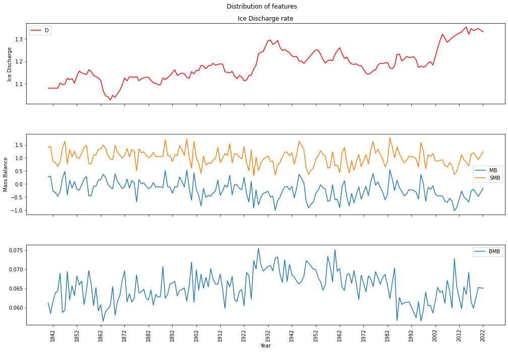

```python
fig, ax = plt.subplots(3,1, figsize=(15,10), sharex = True)
fig.suptitle("Distribution of features")
fig.tight_layout(pad=5.0)

ax[0].plot(dfm.index,dfm["D"],color = 'red', label = "D")
ax[1].plot(dfm.index,dfm["MB"], label = "MB")
ax[1].plot(dfm.index,dfm["SMB"], label = "SMB")
ax[0].legend()
plt.xlabel('Year')
ax[0].set_ylabel('Ice Discharge')
ax[1].set_ylabel('Mass Balance')
ax[0].set_title("Ice Discharge rate")
ax[1].legend()
ax[2].plot(dfm.index,dfm["BMB"], label = "BMB")
plt.xticks(np.arange(1842,2023,10), rotation = 90)
plt.legend()
plt.show()
```

### Correlation between all off them

- we plot them scatter plot between the features to find out how they are correlated.

[figure not shown]

```python
fig,axc = plt.subplots(2,2,figsize=(12,12))
fig.suptitle("Correlation between features",fontsize='large', fontweight='bold')
fig.tight_layout(pad=5.0)

m, b = np.polyfit(dfm["SMB"],dfm["MB"], 1)
axc[0][0].set_title("SMB and MB Correlation",fontsize='large', fontweight='bold')
axc[0][0].set_xlabel("Surface MB",fontsize='large', fontweight='bold')
axc[0][0].set_ylabel("Mass Balance (MB)",fontsize='large', fontweight='bold')
axc[0][0].plot(dfm["SMB"], m*dfm["SMB"]+b, color='red')
axc[0][0].scatter(dfm["SMB"],dfm["MB"])

m, b = np.polyfit(dfm["D"],dfm["MB"], 1)
axc[0][1].set_title("MB and D Correlation",fontsize='large', fontweight='bold')
axc[0][1].set_ylabel("Mass Balance (MB)",fontsize='large', fontweight='bold')
axc[0][1].set_xlabel("Discharge (D)",fontsize='large', fontweight='bold')
axc[0][1].plot(dfm["D"], m*dfm["D"]+b, color='red')
axc[0][1].scatter(dfm["D"],dfm["MB"])

m, b = np.polyfit(dfm["D"],dfm["SMB"], 1)
axc[1][0].set_title("SMB and D Correlation",fontsize='large', fontweight='bold')
axc[1][0].set_ylabel("Surface MB",fontsize='large', fontweight='bold')
axc[1][0].set_xlabel("Discharge (D)",fontsize='large', fontweight='bold')
axc[1][0].plot(dfm["D"], m*dfm["D"]+b, color='red')
axc[1][0].scatter(dfm["D"],dfm["SMB"])

m, b = np.polyfit(dfm["D"],dfm["BMB"], 1)
axc[1][1].set_title("BMB and D Correlation",fontsize='large', fontweight='bold')
axc[1][1].set_ylabel("Basel MB",fontsize='large', fontweight='bold')
axc[1][1].set_xlabel("Discharge (D)",fontsize='large', fontweight='bold')
axc[1][1].plot(dfm["D"], m*dfm["D"]+b, color='red')
axc[1][1].scatter(dfm["D"],dfm["BMB"])

plt.show()
```

- The Mass Balances are positiviely correlated to eachother whereas any Mass Balance with discharge is negatively correlated except for Basel MB.
- From this we can infer that Basel Mass Balance doesn't effect for the ice discharge.
- The discharge is mainly due to the Surface Mass Balance.